# Getting Started Testing in Data Science

# Hypothesis

Automatic data generation for property based testing

```python
from hypothesis import strategies as st


print('Examples of integers:')
print(st.integers().example())
print(st.integers().example())
print(st.integers().example())
```

```
Examples of integers:
12
18697
-127
```

```python
# contents of demo_hypothesis.py
from hypothesis import given
from hypothesis import strategies as st


def backwards_allcaps(text):
    return text[::-1].upper()


@given(st.text())
def test_backwards_allcaps(input_string):
    modified = backwards_allcaps(input_string)
    assert input_string.upper() == ''.join(reversed(modified))
```

[figure not shown]

# Hypothesis + Pandas

```python
from hypothesis.extra.pandas import data_frames, column



data_frames([column('customer',
                    elements=st.integers(min_value=0, max_value=100_000),
                    dtype=int, unique=True),
             column('price', dtype='float'),
             column('prob_return',
                    elements=st.floats(min_value=0, max_value=1))
        ]).example()
```

|  | customer | price | prob_return |
| --- | --- | --- | --- |
| 0 | 80119 | 2.180319e+16 | 0.22176 |
| 1 | 99019 | 2.180319e+16 | 0.22176 |

# Hypothesis + Pandas

```python
from hypothesis.extra.pandas import data_frames, column



data_frames([column('customer',
                    elements=st.integers(min_value=0, max_value=100_000),
                    dtype=int, unique=True),
             column('price', dtype='float'),
             column('prob_return',
                    elements=st.floats(min_value=0, max_value=1))
            ]).example()
```

|  | customer | price | prob_return |
| --- | --- | --- | --- |

# Testing properties of data

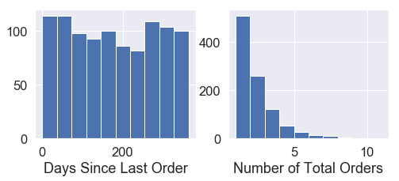

```python
import matplotlib.pyplot as plt
import seaborn as sns


sns.set(font_scale=1.5)

df_customers = pd.DataFrame(
    {'days_since_last_order': np.random.randint(low=0, high=365, size=1000),
     'num_total_orders': np.random.geometric(0.5, size=1000)})

fig, (ax1, ax2) = plt.subplots(1, 2, figsize=(8, 3))
df_customers.days_since_last_order.hist(ax=ax1)
df_customers.num_total_orders.hist(ax=ax2)
ax1.set_xlabel('Days Since Last Order')
ax2.set_xlabel('Number of Total Orders')
plt.show();
```

# Testing properties of data

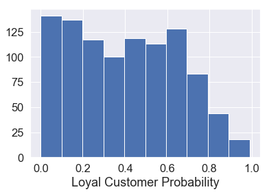

```python
from scipy.special import expit  # logistic function


def probality_loyal_customer(df):
    "Return customer probability of returning."
    p_num_orders = df.num_total_orders.apply(expit)
    p_days_ago = df.days_since_last_order / df.days_since_last_order.max()
    p_loyal = p_days_ago * p_num_orders
    return p_loyal


prob_loyal = probality_loyal_customer(df_customers)
prob_loyal.hist()
plt.xlabel('Loyal Customer Probability');
```

```python
# contents of demo_pandas_hypothesis.py
from hypothesis import given
from hypothesis import strategies as st
from hypothesis.extra.pandas import data_frames, column
from scipy.special import expit


def probability_loyal_customer(df):
    "Return customer probability of returning."
    p_num_orders = df.num_total_orders.apply(expit)
    p_days_ago = df.days_since_last_order / df.days_since_last_order.max()
    p_loyal = p_days_ago * p_num_orders
    return p_loyal


@given(
    data_frames([
        column('days_since_last_order', dtype=int,
               elements=st.integers(min_value=0, max_value=365)),
        column('num_total_orders', dtype=int,
               elements=st.integers(min_value=0, max_value=1_000_000))])
)
def test_prob_loyality(df):
    p = probability_loyal_customer(df)
    assert p.between(0, 1, inclusive=True).all()
```

[figure not shown]

# Wrap Up

- data scientists should not *always* write tests
  - (but we should always practice defensive programming)
- any reused or shared piece of code should probably be tested, especially in production
- strive for a balance between speed and confidence in your results
  - testing can help you acheive this!

### Some aspects of data science code are really hard to test!

- ML results? probabilistic outcomes?
- Think about testing properties of your data
  - distributions, missing data, expected features and datatypes

## Resources & Credits

- **General testing resources**
  - Andreas Pelme's [Introduction to pytest](https://www.youtube.com/watch?v=LdVJj65ikRY) from EuroPython 2014
  - Mark Vousden's [Python testing](https://www.youtube.com/channel/UCKaKhMyhboLoMwmeF9yxg9w) 3-part series of youtube videos
  - Justin Crown's ["WHAT IS THIS MESS?" - Writing tests for pre-existing code bases](https://www.youtube.com/watch?v=LDdUuoI_lIg) from PyCon 2018
  - Ned Batchelder's [Getting Started Testing](https://www.youtube.com/watch?v=FxSsnHeWQBY) from PyCon 2014 (focuses on unittest)
- **Data Science specific resources**
  - Trey Causey's [Testing for Data Scientists](https://www.youtube.com/watch?v=GEqM9uJi64Q) from PyData Seattle 2015
  - Eric Ma's [Best Testing Practice's for Data Science Tutorial](https://www.youtube.com/watch?v=yACtdj1_IxE) from PyCon 2017, with GitHub notebooks [here](https://github.com/ericmjl/data-testing-tutorial)

## Link to my slides/notebook on GitHub

https://github.com/jesford/testing-in-data-science